# Fitting Regression Models to Body Fat Data

Seth Harrison

Last compiled: November 13, 2019

Type complete sentences to answer all questions inside the `answer` tags provided in the R Markdown document. Round all numeric answers you report inside the answer tags to four decimal places. Use inline `R` code to report numeric answers inside the `answer` tags (i.e. do not hard code your numeric answers).

The purpose of this activity is to have the reader create several regression models to predict the body fat of males. Load a cleaned version of the data available from https://raw.githubusercontent.com/alanarnholt/MISCD/master/bodyfatClean.csv into your `R` session using the `read.csv()` function. Use the `head()` function to view the first six rows of the data frame `bodyfatClean`.

```r
bodyFatClean <- read.csv("https://raw.githubusercontent.com/alanarnholt/MISCD/master/bodyfatClean.csv")
```

1. Use the `glimpse()` function from the `dplyr` package written by Wickham et al. (2019) to view the structure of `bodyfatClean`.

```r
library(dplyr)
glimpse(bodyFatClean)
```

```
Observations: 251
Variables: 18
$ age           <int> 23, 22, 22, 26, 24, 24, 26, 25, 25, 23, 26, 27, 32…
$ weight_lbs    <dbl> 154.25, 173.25, 154.00, 184.75, 184.25, 210.25, 18…
$ height_in     <dbl> 67.75, 72.25, 66.25, 72.25, 71.25, 74.75, 69.75, 7…
$ neck_cm       <dbl> 36.2, 38.5, 34.0, 37.4, 34.4, 39.0, 36.4, 37.8, 38…
$ chest_cm      <dbl> 93.1, 93.6, 95.8, 101.8, 97.3, 104.5, 105.1, 99.6,…
$ abdomen_cm    <dbl> 85.2, 83.0, 87.9, 86.4, 100.0, 94.4, 90.7, 88.5, 8…
$ hip_cm        <dbl> 94.5, 98.7, 99.2, 101.2, 101.9, 107.8, 100.3, 97.1…
$ thigh_cm      <dbl> 59.0, 58.7, 59.6, 60.1, 63.2, 66.0, 58.4, 60.0, 62…
$ knee_cm       <dbl> 37.3, 37.3, 38.9, 37.3, 42.2, 42.0, 38.3, 39.4, 38…
$ ankle_cm      <dbl> 21.9, 23.4, 24.0, 22.8, 24.0, 25.6, 22.9, 23.2, 23…
$ biceps_cm     <dbl> 32.0, 30.5, 28.8, 32.4, 32.2, 35.7, 31.9, 30.5, 35…
$ forearm_cm    <dbl> 27.4, 28.9, 25.2, 29.4, 27.7, 30.6, 27.8, 29.0, 31…
$ wrist_cm      <dbl> 17.1, 18.2, 16.6, 18.2, 17.7, 18.8, 17.7, 18.8, 18…
$ brozek_C      <dbl> 12.6, 6.9, 24.6, 10.9, 27.8, 20.5, 19.0, 12.7, 5.1…
$ bmi_C         <dbl> 23.6, 23.3, 24.7, 24.9, 25.5, 26.5, 26.2, 23.5, 24…
$ age_sq        <int> 529, 484, 484, 676, 576, 576, 676, 625, 625, 529, …
$ abdomen_wrist <dbl> 68.1, 64.8, 71.3, 68.2, 82.3, 75.6, 73.0, 69.7, 64…
$ am            <dbl> 181.9365, 169.1583, 195.5067, 182.7203, 190.6993, …
```

Now that you have seen the structure of the data and have studied the research question, answer the following questions.

2. How many observations and variables are in `bodyfatClean`?

```r
# Type your code and comments inside the code chunk
#
```

There are 18 variables and 251 observations.

3. In the regression setting, the variable that we want to predict is called the response variable. What is the name of the response variable in your case?

The response variable is brozek_C.

4. In the regression setting, the variable(s) that we use to predict the response variable is(are) called the explanatory or predictor variable(s). How many predictor variable(s) are available to use in this data set?

5. How many of the predictor variables are numerical and how many of them are categorical?

All of the predictors are numerical.

# 1 Partitioning the Data

When building a predictive model with a sufficiently large data set, it is common practice to hold out some fraction (usually less than 50%) of the data as a test set. It is difficult to provide a general rule for the size of the `training` and `testing` sets as the ideal split depends on the signal to noise ratio in the data (Hastie, Tibshirani, and Friedman 2009).

Use the `creatDataPartition()` function from the `caret` package to partition the data in to `training` and `testing`.

For illustration purposes, the `Boston` data set from the **MASS** package written by Ripley (2019) is used to illustrate various steps in predictive model building. The `Boston` help file indicates the data set consists of 506 observations on 14 different variables for houses in Boston collected in 1978. To open the `Boston` help file, type `?Boston` at the R prompt once the **MASS** package has been loaded. The goal here is to predict the median house price (`medv`) in Boston. The Boston data set is divided into a training set containing roughly 80% of the observations and a testing set containing roughly 20% of the observations. Before calling the `createDataPartition()` function, it is important to set a seed to ensure the data partition is reproducible.

The arguments `y`, `p`, `list` and `times` can be used with the `createDataPartition()` function. These arguments represent a vector of outcomes (`Boston$medv`), the percentage of data that goes to training (`0.80`), should the results be in a list (`FALSE`) and the number of partitions to create (`1`) respectively. The result from using `createDataPartition()` is a vector of indices one can use to create the training set.

```r
library(caret) # load the caret package
library(MASS) # load MASS package
set.seed(3178) # set seed for reproducibility

trainIndexB <- createDataPartition(y = Boston$medv,
                                  p = 0.80,
                                  list = FALSE,
                                  times = 1)

trainingB <- Boston[trainIndexB, ]
testingB <- Boston[-trainIndexB, ]

dim(trainingB) # Check the dimension of the  training set
```

```
[1] 407  14
```

```r
dim(testingB) # Check the dimension of the testing set
```

```
[1] 99 14
```

6. Partition the data frame `bodyfatClean` into training and testing partitions where roughly 80% of the data is used for training and roughly 20% of the data is used for testing. To ensure reproducibility of the partition, use `set.seed(314)`. The response variable should be `brozek_C` (the computed brozek based on the reported density).

```r
set.seed(314) # set seed for reproducibility

trainIndex <- createDataPartition(y = bodyFatClean$brozek_C,
                                  p = 0.80,
                                  list = FALSE,
                                  times = 1)

training <- bodyFatClean[trainIndex, ]
testing <- bodyFatClean[-trainIndex, ]
```

7. Use the `dim()` function to verify the sizes of the `training` and `testing` data sets.

```r
dim(training)
```

```
[1] 203  18
```

```r
dim(testing)
```

```
[1] 48 18
```

The training data set has 203 objects and the testing data set has 48 objects, both have 18 variables.

# 2 Pre-Processing the Data

Some algorithms work better when the predictors are on the same scale. This section considers the `preProcess()` function for the **caret** package to find potentially helpful transformations of the training predictors. Three different transformations are considered: `center`, `scale`, and `BoxCox`. A center transform computes the mean of a variable and subtracts the computed mean from each value of the variable. A scale transform computes the standard deviation of a variable and divides each value of the variable by the computed standard deviation. Using both a center and a scale transform standardizes a variable. That is, using both center and scale on a variable creates a variable with a mean of 0 and a standard deviation of 1. When all values of a variable are positive, a `BoxCox` transform will reduce the skew of a variable, making it more Gaussian.

The following `R` Code applies a `center`, `scale`, and `BoxCox` transform to all the predictors in `trainingB` (the training set for the Boston data) and stores the results in `pp_trainingB`. The computed transformations are applied to both the `trainingB` and the `testingB` data sets using the `predict()` function with the results stored in the objects `trainingTransB` and `testingTransB`, respectively. Note that in the Boston data set the response (`medv`) is the last column ($14^{\text{th}}$) of the training data frame and is removed before pre-processing with `trainingB[ , -14]`.

```r
pp_trainingB <- preProcess(trainingB[ , -14],
                          method = c("center", "scale", "BoxCox"))
pp_trainingB
```

```
Created from 407 samples and 13 variables

Pre-processing:
  - Box-Cox transformation (11)
  - centered (13)
  - ignored (0)
  - scaled (13)

Lambda estimates for Box-Cox transformation:
   Min. 1st Qu.  Median    Mean 3rd Qu.    Max.
-1.0000 -0.2000  0.2000  0.3818  0.9000  2.0000
```

```r
trainingTransB <- predict(pp_trainingB, trainingB)
testingTransB <- predict(pp_trainingB, testingB)
```

Your turn to work with the `bodyfatClean` data frame now.

8. Provide the column number of `bodyfatClean` where `brozek_C` is stored.

```r
# Type your code and comment inside the code chunk
#
```

brozek_C is stored in the 14th column.

9. Use the `preProcess()` function to transform the predictors that are in the `training` data set crated in Problem 6. Specifically, pass a vector with “center”, “scale”, and “BoxCox” to the `method =` argument of `preProcess()`. Make sure not to transform the response (`brozek_C`). Store the results in an object named `pp_training`.

```r
pp_training <- preProcess(training[ , -14],
                          method = c("center", "scale", "BoxCox"))
```

10. Use the `predict()` function to construct a transformed training set and a transformed testing set. Name the new transformed data sets `trainingTrans` and `testingTrans`, respectively.

```r
trainingTrans <- predict(pp_training, training)
testingTrans <- predict(pp_training, testing)
```

# 3 $k$-Fold Cross Validation

$k$-fold cross validation divides the data into $k$ subsets and performs the holdout method $k$ times. Specifically, one of the $k$ subsets is used as the test set and the other $k − 1$ subsets are put together to form a training set. The average MSE across all $k$ trials is computed and is denoted $CV_{(k)}$

# 4 Resampling with caret

The `trainControl()` function from **caret** specifies the resampling procedure to be used inside the `train()` function. Resampling procedures include $k$-fold cross-validation (once or repeated), leave-one-out cross-validation, and bootstrapping. The following `R` code creates a `myControlB` object that will signal a 10-fold repeated five times cross-validation scheme (50 resamples in total) to the `train()` function for the `Boston` data set. Note that the argument `savePredictions = "final"` saves the hold-out predictions for the optimal tuning parameters.

```r
myControlB <- trainControl(method = "repeatedcv",
                          number = 10,
                          repeats = 5,
                          savePredictions = "final")
```

11. Use the `trainControl()` function to define the resampling method (repeated cross-validation), the number of resampling iterations (10), and the number of repeats or complete sets to generate (5), storing the results in the object `myControl`.

```r
myControl <- trainControl(method = "repeatedcv",
                          number = 10,
                          repeats = 5,
                          savePredictions = "final")
```

# 5 Building Linear Models

## 5.1 Least squares model

Let’s denote the response variable by $Y$ (always quantitative). $p$ predictor variables will be denoted by $X_1, X_2,\ldots, X_p$ (all quantitative). Some authors refer to the response variable as the dependent variable while the predictor variables are sometimes referred to as independent variables, explanatory variables, features or covariates. The relationship between $Y$ and $X_1, X_2,\ldots, X_p$ will be expressed as

$$\begin{equation}
Y = f(X_1, X_2,\ldots, X_p) + \epsilon.
\tag{5.1}
\end{equation}$$

In (5.1) $f$ is some fixed but unknown function of $X_1, X_2,\ldots, X_p$, and $\epsilon$ is a random error term independent of $X_1, X_2,\ldots, X_p$ with mean zero. For predictive models, the goal is to estimate $f$ with $\hat{f}$ so that $\hat{Y} = \hat{f}(X_1, X_2,\ldots, X_p)$ yields accurate predictions for $Y$. If one assumes $f$ is linear in $X_1, X_2,\ldots, X_p$, the model is expressed as the linear model as shown in (5.2).

$$\begin{equation}
Y = f(X) = \beta_0 + \beta_1X_1 + \beta_2X_2 + \cdots + \beta_pX_p + \epsilon
\tag{5.2}
\end{equation}$$

By assuming the functional form of $f$ is linear, the problem becomes one of finding estimates for the parameters $\beta_0, \beta_1, \ldots, \beta_p$ which is generally done with least squares. The least squares estimators are obtained by minimizing the sum of squared residuals (RSS), where

$$\begin{equation}
\text{RSS} = \sum_{i=1}^n(y_i-\hat{y}_i)^2,
\tag{5.3}
\end{equation}$$

and $\hat{y}_i = \hat\beta_0 + \hat\beta_1X_1 + \hat\beta_2X_2 + \cdots + \hat\beta_pX_p.$

To fit a model with a particular algorithm, the name of the algorithm is given to the `method` argument of the `train()` function. The `train()` function accepts a formula interface provided the data is also specified in the function. Following R Code fits a linear model by regressing `medv` on all of the predictors in the training data set using the dot indicator which selects all predictors `(medv ∼ .)`. The preferred way to train a model is by passing the response vector to the `y` argument and a data frame of the predictors or a matrix of the predictors to the `x` argument of `train()`. Both approaches are shown in the below `R` code.

```r
# Here we used  method = "lm" to fit a Least Squares Regression model

# Approach 1
set.seed(31)
mod_lm <- train(medv ~ .,
                data = trainingTransB,
                trControl = myControlB,
                method = "lm")

# Approach 2
set.seed(31)
mod_lm2 <- train(y = trainingTransB$medv,    # response
                 x = trainingTransB[, -14],  # predictors
                 trControl = myControlB,
                 method = "lm")

mod_lm2$results       # CV results
```

```
  intercept     RMSE  Rsquared      MAE    RMSESD RsquaredSD     MAESD
1      TRUE 4.455474 0.7665707 3.270938 0.6823905 0.07597021 0.3969299
```

```r
mod_lm2$results$RMSE  # RMSE
```

```
[1] 4.455474
```

The average root mean squared error (RMSE) of the 50 resamples is 4.4555.

```r
summary(mod_lm2)  # summary of lm object
```

```
Call:
lm(formula = .outcome ~ ., data = dat)

Residuals:
     Min       1Q   Median       3Q      Max
-12.3469  -2.5041  -0.3544   2.0806  23.6608

Coefficients:
            Estimate Std. Error t value Pr(>|t|)
(Intercept) 22.43857    0.21712 103.344  < 2e-16 ***
crim         0.02023    0.59411   0.034 0.972855
zn           0.09676    0.31164   0.310 0.756355
indus       -0.58197    0.43290  -1.344 0.179606
chas         0.33047    0.22619   1.461 0.144806
nox         -1.82660    0.56902  -3.210 0.001436 **
rm           1.88904    0.30833   6.127 2.18e-09 ***
age          0.27190    0.41010   0.663 0.507716
dis         -3.19368    0.49404  -6.464 3.02e-10 ***
rad          1.46671    0.47024   3.119 0.001948 **
tax         -1.70077    0.45314  -3.753 0.000201 ***
ptratio     -1.86321    0.27141  -6.865 2.61e-11 ***
black        0.78819    0.25739   3.062 0.002348 **
lstat       -5.25559    0.39080 -13.448  < 2e-16 ***
---
Signif. codes:  0 '***' 0.001 '**' 0.01 '*' 0.05 '.' 0.1 ' ' 1

Residual standard error: 4.38 on 393 degrees of freedom
Multiple R-squared:  0.7792,    Adjusted R-squared:  0.7719
F-statistic: 106.7 on 13 and 393 DF,  p-value: < 2.2e-16
```

12. Use the `train()` function with `method = "lm"` and assign the object `myControl` to the `trControl` argument of the `train()` function to fit a least squares regression model where the goal is to predict body fat using the pre-processed data in `trainingTrans` created in Problem 10. Use `brozek_C` as the response and store the results of `train()` in `mod_lm`. Use `set.seed(42)` for reproducibility. Use `mod_lm$results` to investigate the model with minimum RMSE. Use the `summary()` function to view the coefficient estimates of the final model.

```r
set.seed(42)
mod_lm <- train(brozek_C ~ .,
                data = trainingTrans,
                trControl = myControl,
                method = "lm")
mod_lm$results
```

```
  intercept     RMSE  Rsquared      MAE    RMSESD RsquaredSD     MAESD
1      TRUE 3.893588 0.7314802 3.249845 0.5303373 0.08236035 0.4774492
```

```r
summary(mod_lm)
```

```
Call:
lm(formula = .outcome ~ ., data = dat)

Residuals:
    Min      1Q  Median      3Q     Max
-8.1911 -2.5964 -0.1234  2.6997  9.2946

Coefficients: (1 not defined because of singularities)
              Estimate Std. Error t value Pr(>|t|)
(Intercept)    18.8217     0.2668  70.557  < 2e-16 ***
age             1.1473     0.4064   2.823  0.00527 **
weight_lbs    -18.6657    14.2607  -1.309  0.19219
height_in       4.0826     6.8457   0.596  0.55165
neck_cm        -1.0010     0.5284  -1.894  0.05973 .
chest_cm       -1.3732     0.8156  -1.684  0.09394 .
abdomen_cm      6.5655    34.5126   0.190  0.84933
hip_cm         -0.4263     0.9690  -0.440  0.66049
thigh_cm        0.4715     0.7504   0.628  0.53055
knee_cm        -0.5590     0.6289  -0.889  0.37526
ankle_cm        0.5386     0.4749   1.134  0.25815
biceps_cm       0.2518     0.4981   0.506  0.61381
forearm_cm      0.2837     0.4491   0.632  0.52838
wrist_cm       -1.9132     3.1708  -0.603  0.54700
bmi_C          39.0678    20.2574   1.929  0.05531 .
age_sq              NA         NA      NA       NA
abdomen_wrist   0.7118    32.6770   0.022  0.98264
am            -22.3401    13.4754  -1.658  0.09903 .
---
Signif. codes:  0 '***' 0.001 '**' 0.01 '*' 0.05 '.' 0.1 ' ' 1

Residual standard error: 3.801 on 186 degrees of freedom
Multiple R-squared:  0.7576,    Adjusted R-squared:  0.7368
F-statistic: 36.33 on 16 and 186 DF,  p-value: < 2.2e-16
```

13. Use the `corrplot()` function from the `corrplot` package written by Wei and Simko (2017) to identify predictors that may be linearly related in `trainingTrans`. Are any of the variables colinear? If so, remove the predictor that is least correlated to the response variable. Note that when `method = "number"` is used with `corrplot()`, color coded numerical correlations are displayed.

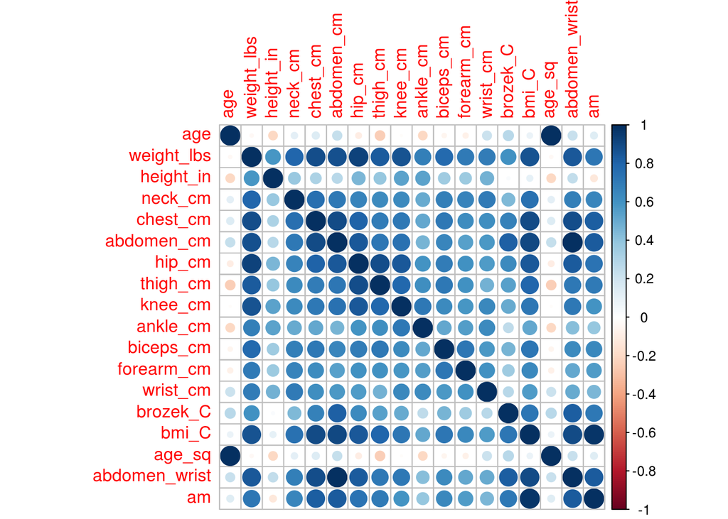

```r
library(corrplot)
trainingTransC <- cor(trainingTrans)
corrplot(trainingTransC)
```

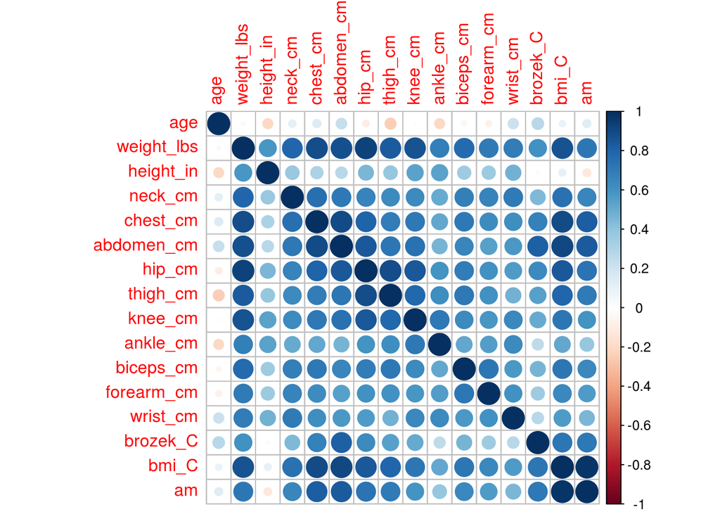

```r
trainingTransC <- trainingTrans[ , -16]
trainingTransC <- trainingTransC[ , -16]
trainingTransC <- cor(trainingTransC)
corrplot(trainingTransC)
```

`age_sq` and `age` appear to be colinear, as well as `abdomen_cm` and abdomen_wrist. `age_sq` and `abdomen_wrist` are the least correlated so those will be removed.

## 5.2 Forward selection

Forward selection starts with the null model (a model created from regressing the response on the intercept) then adds predictors one at a time to the model by regressing the response on all of the possible predictors one at a time and adding the predictor that makes the *RSS* as small as possible or that creates the largest $R^2$. This process continues until all variables have been added to the model or a criterion such as a p-value greater than some predetermined value (such as 0.20) tells the algorithm to stop adding variables to the model.

13. Use the `train()` function with `method = "leapForward"`, `tuneLength = 10` and assign the object `myControl` to the `trControl` argument of the `train()` function to fit a forward selection model where the goal is to predict body fat using the pre-processed data `trainingTrans` from Problem 10. Use `brozek_C` as the response variable and store the results of `train()` in `mod_FS`. Use `set.seed(42)` for reproducibility. Do not include any predictors that are perfectly correlated.
    1. Use `mod_FS$results` to investigate the model that resulted in the minimum RMSE (final submodel).
    2. Use `mod_FS$bestTune` to find out how many variable were selected in the final submodel (`nvmax`).
    3. Use the `summary(mod_FS)` function and find the names of the variables selected in the final submodel with minimum RMSE. (Hint: Go to the part the output under `Selection Algorithm: forward`, then look at the row which agrees with the `nvmax` from B. The variables with `"*"`s are the variables selected in the final submodel.) To find the actual coefficients, one can use `coef(mod_FS$finalModel, id = mod_FS$bestTune$nvmax)`.

```r
set.seed(42)
mod_FS <- train(brozek_C ~.,
                data = trainingTrans,
                tunelength = 10,
                trcontrol = myControl,
                method = "leapForward")
```

[output not shown]

A

```r
mod_FS$results
```

```
  nvmax     RMSE  Rsquared      MAE    RMSESD RsquaredSD     MAESD
1     2 5.107946 0.5322005 4.229178 0.4559505 0.09798713 0.4189870
2     3 4.882205 0.5712756 4.011066 0.5539940 0.10141331 0.4841092
3     4 4.685027 0.6064734 3.837571 0.6359306 0.09687581 0.5247741
```

The best model produced by forward selection has an RMSE of 4.6850272

B

```r
mod_FS$bestTune
```

```
  nvmax
3     4
```

There were four variables selected in the final model.

C

```r
summary(mod_FS)
```

```
Subset selection object
17 Variables  (and intercept)
              Forced in Forced out
age               FALSE      FALSE
weight_lbs        FALSE      FALSE
height_in         FALSE      FALSE
neck_cm           FALSE      FALSE
chest_cm          FALSE      FALSE
abdomen_cm        FALSE      FALSE
hip_cm            FALSE      FALSE
thigh_cm          FALSE      FALSE
knee_cm           FALSE      FALSE
ankle_cm          FALSE      FALSE
biceps_cm         FALSE      FALSE
forearm_cm        FALSE      FALSE
wrist_cm          FALSE      FALSE
bmi_C             FALSE      FALSE
abdomen_wrist     FALSE      FALSE
am                FALSE      FALSE
age_sq            FALSE      FALSE
1 subsets of each size up to 5
Selection Algorithm: forward
         age weight_lbs height_in neck_cm chest_cm abdomen_cm hip_cm
1  ( 1 ) " " " "        " "       " "     " "      " "        " "
2  ( 1 ) " " "*"        " "       " "     " "      " "        " "
3  ( 1 ) " " "*"        " "       " "     " "      " "        " "
4  ( 1 ) "*" "*"        " "       " "     " "      " "        " "
5  ( 1 ) "*" "*"        " "       " "     " "      " "        " "
         thigh_cm knee_cm ankle_cm biceps_cm forearm_cm wrist_cm bmi_C
1  ( 1 ) " "      " "     " "      " "       " "        " "      " "
2  ( 1 ) " "      " "     " "      " "       " "        " "      " "
3  ( 1 ) " "      " "     " "      " "       " "        "*"      " "
4  ( 1 ) " "      " "     " "      " "       " "        "*"      " "
5  ( 1 ) " "      " "     " "      " "       " "        "*"      "*"
         age_sq abdomen_wrist am
1  ( 1 ) " "    "*"           " "
2  ( 1 ) " "    "*"           " "
3  ( 1 ) " "    "*"           " "
4  ( 1 ) " "    "*"           " "
5  ( 1 ) " "    "*"           " "
```

```r
coef(mod_FS$finalModel, id = mod_FS$bestTune$nvmax)
```

[output not shown]

16. Compute the RMSE for `mod_FS` using the `testing` data set.

```r
p <- predict(mod_FS, testingTrans)
error <- p - bodyFatClean[["brozek_C"]]
MRSEtfs <- sqrt(mean(error)^2)
```

## 5.3 Backward elimination

Backward elimination starts with all predictors in the model (full model) and removes the least significant variables one at a time. The algorithm stops removing variables once a stopping criterion such as p-value less than some predetermined value (such as 0.05) for all predictors in the model is achieved. When the data has more predictors ($p$) than observations ($n$), backward elimination is no longer a viable approach since the least squares estimates are not unique. While forward selection is a viable approach when $n < p$, constrained regression is sometimes a better choice by increasing the bias for a relatively large reduction in variance.

17. Use the `train()` function with `method = "leapBackward"`, `tuneLength = 10` and assign the object `myControl` to the `trControl` argument of the `train()` function to fit a backward selection model where the goal is to predict body fat. Use `brozek_C` as the response and store the results of `train()` in `mod_BE`. Use `set.seed(42)` for reproducibility. Do not include any predictors that are perfectly correlated.
    1. Use `mod_BE$results` to investigate which model results in the minimum RMSE (final submodel).
    2. Use `mod_BE$bestTune` to find out how many variable were selected to the final submodel (`nvmax`)?
    3. Use the `summary(mod_BE)` function and find the names of the variables selected in the final submodel with minimum RMSE. (Hint: Go to the part the output under `Selection Algorithm: backward`, then look at the row which agrees with the `nvmax` from B. The variables with `"*"`s are the variables selected in the final submodel.) To find the actual coefficients, one can use `coef(mod_BE$finalModel, id = mod_BE$bestTune$nvmax)`.

```r
mod_BE <- train(brozek_C ~ .,
                data = trainingTrans,
                tunelength = 10,
                trcontrol = myControl,
                method = "leapBackward")
```

[output not shown]

```r
mod_BE$results
```

```
  nvmax     RMSE  Rsquared      MAE    RMSESD RsquaredSD     MAESD
1     2 4.413062 0.6424138 3.626509 0.5427495 0.09668458 0.4592004
2     3 4.371528 0.6482847 3.596834 0.5293296 0.09194018 0.4355159
3     4 4.247101 0.6689773 3.490898 0.4183242 0.06776680 0.3317865
```

The best model produced by backward selection has an RMSE of 4.247101

```r
mod_BE$bestTune
```

```
  nvmax
3     4
```

There were four variables selected in the final model.

```r
summary(mod_BE)
```

```
Subset selection object
17 Variables  (and intercept)
              Forced in Forced out
age               FALSE      FALSE
weight_lbs        FALSE      FALSE
height_in         FALSE      FALSE
neck_cm           FALSE      FALSE
chest_cm          FALSE      FALSE
abdomen_cm        FALSE      FALSE
hip_cm            FALSE      FALSE
thigh_cm          FALSE      FALSE
knee_cm           FALSE      FALSE
ankle_cm          FALSE      FALSE
biceps_cm         FALSE      FALSE
forearm_cm        FALSE      FALSE
wrist_cm          FALSE      FALSE
bmi_C             FALSE      FALSE
abdomen_wrist     FALSE      FALSE
am                FALSE      FALSE
age_sq            FALSE      FALSE
1 subsets of each size up to 5
Selection Algorithm: backward
         age weight_lbs height_in neck_cm chest_cm abdomen_cm hip_cm
1  ( 1 ) " " " "        " "       " "     " "      "*"        " "
2  ( 1 ) " " " "        " "       " "     " "      "*"        " "
3  ( 1 ) "*" " "        " "       " "     " "      "*"        " "
4  ( 1 ) "*" " "        " "       " "     " "      "*"        " "
5  ( 1 ) "*" " "        " "       "*"     " "      "*"        " "
         thigh_cm knee_cm ankle_cm biceps_cm forearm_cm wrist_cm bmi_C
1  ( 1 ) " "      " "     " "      " "       " "        " "      " "
2  ( 1 ) " "      " "     " "      " "       " "        "*"      " "
3  ( 1 ) " "      " "     " "      " "       " "        "*"      " "
4  ( 1 ) " "      " "     " "      " "       " "        "*"      "*"
5  ( 1 ) " "      " "     " "      " "       " "        "*"      "*"
         age_sq abdomen_wrist am
1  ( 1 ) " "    " "           " "
2  ( 1 ) " "    " "           " "
3  ( 1 ) " "    " "           " "
4  ( 1 ) " "    " "           " "
5  ( 1 ) " "    " "           " "
```

```r
coef(mod_BE$finalModel, id = mod_BE$bestTune$nvmax)
```

```
(Intercept)         age  abdomen_cm    wrist_cm       bmi_C
  18.821675    1.103965    5.965934   -2.367517    1.283924
```

The four variables selected by backwards selection are `age`, `abdomen_cm`, `wrist_cm`, and `bmi_c`.

18. Compute the RMSE for `mod_BE` using the `testing` data set.

```r
p <- predict(mod_BE, testingTrans)
error <- p - bodyFatClean[["brozek_C"]]
MRSEbes <- sqrt(mean(error)^2)
```

## 5.4 Constrained Regression

Constrained regression shrinks the coefficient estimates towards zero while reducing their variance by adding a small amount of bias. Two popular forms of constrained regression are ridge regression developed by Hoerl and Kennard (1970) and the least absolute shrinkage and selection operator (lasso) developed by Tibshirani (1996).

### 5.4.1 Ridge Regression

The ridge regression coefficient estimates denoted by $\hat{\beta}^R$ are values that minimize
$$\begin{equation}
\sum_{i=1}^n(y_i-\hat{y}_i)^2 + \lambda\sum_{j=1}^p\beta^2_j = RSS + \lambda\sum_{j=1}^p\beta^2_j,
\tag{5.4}
\end{equation}$$

where $\lambda \ge 0$ is a tuning parameter. Similar to least squares, ridge regression seeks estimates that make RSS small. However, the quantity $\lambda\sum_{j=1}^p\beta^2_j$ is small when the estimates of the $\beta$’s are close to zero. That is, the quantity $\lambda\sum_{j=1}^p\beta^2_j$ is a shrinkage penalty. When $\lambda = 0$, there is no penalty and ridge regression will return the least squares estimates. As $\lambda \rightarrow \infty$, the shrinkage penalty grows and the estimates of the $\beta$’s approach zero. While least squares regression returns one set of estimates for the $\beta$’s, ridge regression returns a different set of estimates, $\hat{\beta}^R$, for each value of $\lambda$. Selecting a good value of $\lambda$ can be accomplished with cross-validation. The final model with ridge regression will include all $p$ predictors. The penalty used by ridge regression is known as an $\ell_2$ norm. Using an $\ell_1$ norm for the shrinkage penalty instead of an $\ell_2$ norm, results in the lasso model (Tibshirani 1996).

### 5.4.2 LASSO

The lasso coefficients, $\hat{\beta}^L$, minimize the quantity

$$\begin{equation}
\sum_{i=1}^n(y_i-\hat{y}_i)^2 + \lambda\sum_{j=1}^p|\beta_j| = RSS + \lambda\sum_{j=1}^p|\beta_j|
\tag{5.5}
\end{equation}$$

As with ridge regression, lasso returns a set of coefficient estimates, $\hat{\beta}^L$, for each value of $\lambda$. Selecting a good value of $\lambda$ (known as tuning) can be accomplished with cross-validation. Unlike the final ridge regression model which includes all $p$ predictors, the lasso model performs variable selection and returns coefficient estimates for only a subset of the original predictors making the final model easier to interpret. Unfortunately, the lasso does not handle correlated variables very well (Hastie, Tibshirani, and Wainwright 2015). The elastic net (Zou and Hastie 2005) provides a compromise between ridge and lasso penalties.

### 5.4.3 Elastic net

The elastic net minimizes the quantity

$$\begin{equation}
\frac{1}{2}\sum_{i=1}^n(y_i-\hat{y}_i)^2 + \lambda\left[\frac{1}{2}(1 - \alpha)||\beta||_2^2 + \alpha||\beta||_1 \right] ,
\tag{5.6}
\end{equation}$$

where $||\beta||_2^2$ is the $\ell_2$ norm of $\beta$, $\sum_{j=1}^p\beta^2_j$, and $||\beta||_1$ is the $\ell_1$ norm of $\beta$, $\sum_{j=1}^p|\beta_j|$. The penalty applied to an individual coefficient ignoring the value of $\lambda$ is

$$\begin{equation}
\frac{1}{2}(1 - \alpha)\beta_j^2 + \alpha|\beta_j|.
\tag{5.7}
\end{equation}$$

When $\alpha = 1$, the penalty in (5.7) reduces to the lasso penalty, and when $\alpha = 0$, the penalty in (5.7) reduces to the ridge penalty. Selecting good values of $\alpha$ and $\lambda$ can be accomplished with cross-validation.

The following `R` code fits a ridge regression model for `medv` using the `Boston` data with the `train()` function and `method = "glmnet"`. In the `expand.grid()` function, use the argument `alpha = 0` to specify a ridge model. `lambda = seq(0.01, 100, length = 100)` creates a user defined grid of `lambda` values used in tuning the ridge regression.

```r
# Type your code and comments inside the code chunk
# Fit constrained model (elastic net)---Ridge model
set.seed(42)
mod_RidgeB <- train(y =trainingTransB$medv,  # response
                x = trainingTransB[, -14],   # predictors
                trControl = myControlB,
                method = "glmnet",
                tuneGrid = expand.grid(alpha =0, lambda = seq(0.01, 100, length = 100)))
head(mod_RidgeB$results)
```

```
  alpha lambda     RMSE  Rsquared      MAE    RMSESD RsquaredSD     MAESD
1     0   0.01 4.470416 0.7669122 3.175736 0.8655172 0.08205197 0.4677635
2     0   1.02 4.494586 0.7653185 3.164368 0.8960152 0.08546789 0.4783195
3     0   2.03 4.595659 0.7589607 3.182070 0.9660910 0.09454390 0.4996302
4     0   3.04 4.704761 0.7524026 3.237340 1.0050954 0.10070637 0.5071249
5     0   4.05 4.813474 0.7459311 3.301471 1.0291498 0.10529181 0.5105388
6     0   5.06 4.918962 0.7395820 3.370716 1.0450521 0.10892571 0.5108827
```

```r
min(mod_RidgeB$results$RMSE)
```

```
[1] 4.470416
```

```r
mod_RidgeB$bestTune
```

```
  alpha lambda
1     0   0.01
```

```r
mod_RidgeB$bestTune$lambda
```

```
[1] 0.01
```

```r
mod_RidgeB$bestTune$alpha
```

```
[1] 0
```

`mod_Ridge$results` displays the `RMSE` for all the models for each value of the tuning parameter `lambda` (100 models in this case). `mod_RidgeB$bestTune` gives the `lambda` value of the model with the minimum `RMSE`. In this case, the best `lambda` value was 0.01 which resulted the minimum `RMSE` of 4.4704159.

19. Use the `train()` function with `method = "glmnet"` to fit a constrained linear regression model named `mod_Ridge`. Assign the object `myControl` to the `trControl` argument of the `train()` function to fit a ridge model where the goal is to predict body fat. Use `brozek_C` as the response and store the results of `train()` in `mod_Ridge`. Use `set.seed(42)` for reproducibility. Do not include any predictors that are perfectly correlated.

```r
# Type your code and comments inside the code chunk
# Ridge model
#
#
```

19. Give the `lambda` value of the model with the minimum `RMSE`.

```r
# Type your code and comments inside the code chunk
#
```

20. Use the `train()` function with `method = "glmnet"` and assign the object `myControl` to the `trControl` argument of the `train()` function to fit a lasso model where the goal is to predict body fat. Use `brozek_C` as the response and store the results of `train()` in `mod_lasso`. In the `expand.grid()` function set the argument `alpha = 1` in order to obtain a lasso model. Use `set.seed(42)` for reproducibility. Do not include any predictors that are perfectly correlated.

```r
# Type your code and comments inside the code chunk
# Lasso model
#
```

21. Give the `lambda` value of the model with the minimum `RMSE`.

```r
# Type your code and comments inside the code chunk
#
```

22. Use the `train()` function with `method = "glmnet"` and assign the object `myControl` to the `trControl` argument of the `train()` fucntion where the goal is to predict body fat using an elastic net model. Use `brozek_C` as the response and store the results of `train()` in `mod_EN`. Use `set.seed(42)` for reproducibility. Do not include any predictors that are perfectly correlated. Use a custom tuning grid with arguments to `expand.grid()` of `alpha = seq(0.1, 0.5, length = 11)` and `lambda = seq(0.01, 100, length = 20)`.

```r
# Type your code and comments inside the code chunk
# Elastic net model
#
```

21. Report the `lambda` and `alpha` values of the model with the minimum `RMSE`.

```r
# Type your code and comments inside the code chunk
#
```

This material is released under an [Attribution-NonCommercial-ShareAlike 3.0 United States](https://creativecommons.org/licenses/by-nc-sa/3.0/us/) license. Original author: [Alan T. Arnholt](https://alanarnholt.github.io/)

## References

Hastie, Trevor, Robert Tibshirani, and Jerome Friedman. 2009. *The Elements of Statistical Learning: Data Mining, Inference, and Prediction, Second Edition*. 2 edition. Springer.

Hastie, Trevor, Robert Tibshirani, and Martin Wainwright. 2015. *Statistical Learning with Sparsity: The Lasso and Generalizations*. 1 edition. Boca Raton: Chapman; Hall/CRC.

Hoerl, Arthur E., and Robert W. Kennard. 1970. “Ridge Regression: Biased Estimation for Nonorthogonal Problems.” *Technometrics* 12 (1): 55–67. doi:10.2307/1267351.

Johnson, Roger W. 1996. “Fitting Percentage of Body Fat to Simple Body Measurements.” *Journal of Statistics Education* 4 (1). doi:10.1080/10691898.1996.11910505.

Matloff, Norman. 2017. *Statistical Regression and Classification: From Linear Models to Machine Learning*. 1 edition. Boca Raton: Chapman; Hall/CRC.

Ripley, Brian. 2019. *MASS: Support Functions and Datasets for Venables and Ripley’s Mass*. https://CRAN.R-project.org/package=MASS.

Tibshirani, Robert. 1996. “Regression Shrinkage and Selection via the Lasso.” *Journal of the Royal Statistical Society. Series B (Methodological)* 58 (1): 267–88. http://www.jstor.org/stable/2346178.

Wei, Taiyun, and Viliam Simko. 2017. *Corrplot: Visualization of a Correlation Matrix*. https://CRAN.R-project.org/package=corrplot.

Wickham, Hadley, Romain François, Lionel Henry, and Kirill Müller. 2019. *Dplyr: A Grammar of Data Manipulation*. https://CRAN.R-project.org/package=dplyr.

Zou, Hui, and Trevor Hastie. 2005. “Regularization and Variable Selection via the Elastic Net.” *Journal of the Royal Statistical Society: Series B (Statistical Methodology)* 67 (2): 301–20. doi:10.1111/j.1467-9868.2005.00503.x.